# When and Where are Passengers Riding Uber the Most?

Sujay Desai

6/27/2020

In this investigation, R was employed on Uber ride data to determine how time affected customer trip and understand how various users made trips from different bases.

## Library Dependencies

The following R libraries were used in addition to RStudio to conduct the analysis: ggplot2, ggthemes, lubridate, dplyr, tidyr, DT, and scales.

```r
# Load dependent libraries
library(ggplot2)
library(ggthemes)
library(lubridate)
library(dplyr)
library(tidyr)
library(DT)
library(scales)
```

## Data

This dataset for Uber Pickups in New York City was obtained from Kaggle. This data had 4 separate variables and over 4.5 million observations. The data from 6 separate months was combined into one dataframe.

```r
# Create a vector of colors that will be used in the plotting function
colors = c("#CC1011", "#665555", "#05a399", "#cfcaca", "#f5e840", "#0683c9", "#e075b0")

# Read several csv files that contain the data from April 2014 to September 2014
apr_data = read.csv("uber-raw-data-apr14.csv")
may_data = read.csv("uber-raw-data-may14.csv")
jun_data = read.csv("uber-raw-data-jun14.csv")
jul_data = read.csv("uber-raw-data-jul14.csv")
aug_data = read.csv("uber-raw-data-aug14.csv")
sep_data = read.csv("uber-raw-data-sep14.csv")

# Combine data into one dataframe
data_2014 = rbind(apr_data,may_data, jun_data, jul_data, aug_data, sep_data)
```

## Create new columns for individual time objects

```r
#Format Date.Time column
data_2014$Date.Time = as.POSIXct(data_2014$Date.Time, format = "%m/%d/%Y %H:%M:%S")
data_2014$Time = format(as.POSIXct(data_2014$Date.Time, format = "%m/%d/%Y %H:%M:%S"), format="%H:%M:%S")
data_2014$Date.Time = ymd_hms(data_2014$Date.Time)

# Create factors of time objects
data_2014$day = factor(day(data_2014$Date.Time))
data_2014$month = factor(month(data_2014$Date.Time, label = TRUE))
data_2014$year = factor(year(data_2014$Date.Time))
data_2014$dayofweek = factor(wday(data_2014$Date.Time, label = TRUE))

data_2014$hour = factor(hour(hms(data_2014$Time)))
data_2014$minute = factor(minute(hms(data_2014$Time)))
data_2014$second = factor(second(hms(data_2014$Time)))
```

## Analyze number of trips over different groups of time periods

### Visualize the number of trips that passengers made in a day

```r
# Use ggplot to plot the number of trips that passengers made in a day
# Use dplyr to aggregate data
hour_data = data_2014 %>%
  group_by(hour) %>%
    dplyr::summarize(Total = n())
datatable(hour_data)
```

|  | hour | Total |
| --- | --- | --- |
| 1 | 0 | 103836 |
| 2 | 1 | 67227 |
| 3 | 2 | 45865 |
| 4 | 3 | 48287 |
| 5 | 4 | 55230 |
| 6 | 5 | 83939 |
| 7 | 6 | 143213 |
| 8 | 7 | 193094 |
| 9 | 8 | 190504 |
| 10 | 9 | 159967 |

[output cut: 14 more lines]

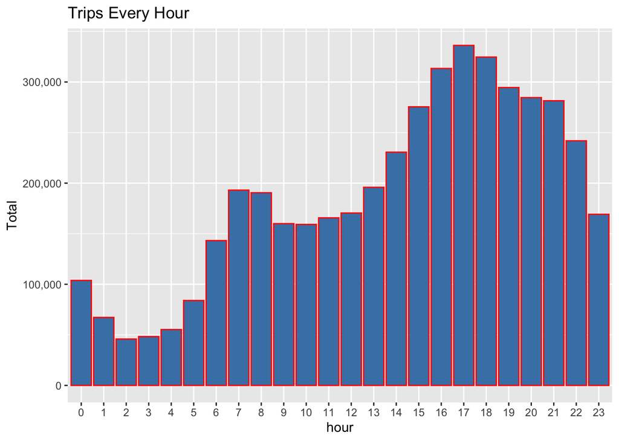

```r
ggplot(hour_data, aes(hour, Total)) +
  geom_bar( stat = "identity", fill = "steelblue", color = "red") +
  ggtitle("Trips Every Hour") +
  theme(legend.position = "none") +
  scale_y_continuous(labels = comma)
```

```r
month_hour = data_2014 %>%
  group_by(month, hour) %>%
    dplyr::summarize(Total = n())
```

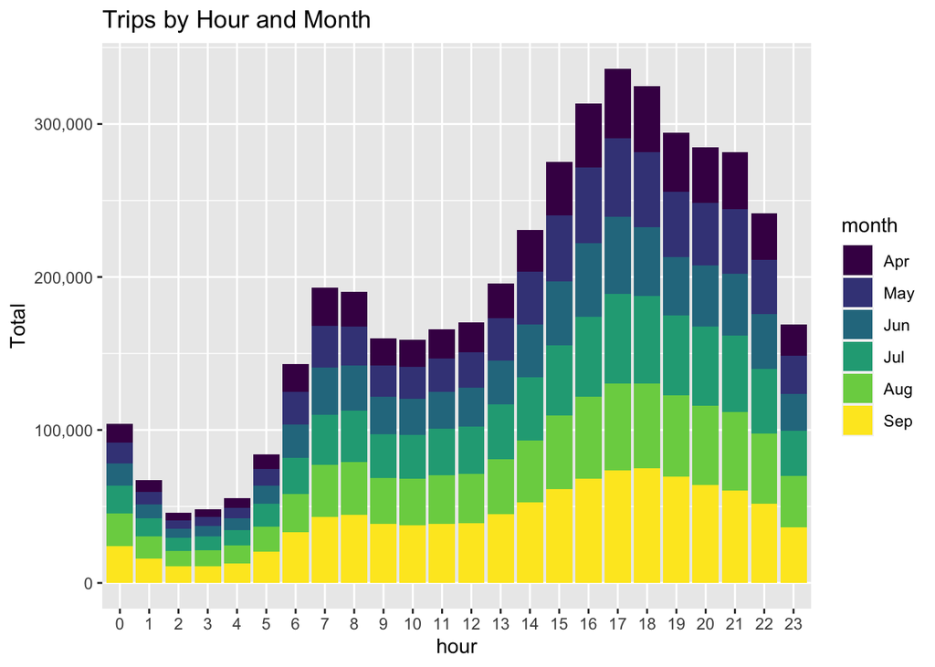

```r
ggplot(month_hour, aes(hour, Total, fill = month)) +
  geom_bar( stat = "identity") +
  ggtitle("Trips by Hour and Month") +
  scale_y_continuous(labels = comma)
```

We can see how the number of passengers fares vary throughout the day. The number of trips are higher in the evening around 5:00 and 6:00 PM.

### Visualize the number of trips during every day of the month

```r
day_group = data_2014 %>%
  group_by(day) %>%
    dplyr::summarize(Total = n())
datatable(day_group)
```

|  | day | Total |
| --- | --- | --- |
| 1 | 1 | 127430 |
| 2 | 2 | 143201 |
| 3 | 3 | 142983 |
| 4 | 4 | 140923 |
| 5 | 5 | 147054 |
| 6 | 6 | 139886 |
| 7 | 7 | 143503 |
| 8 | 8 | 145984 |
| 9 | 9 | 155135 |
| 10 | 10 | 152500 |

[output cut: 21 more lines]

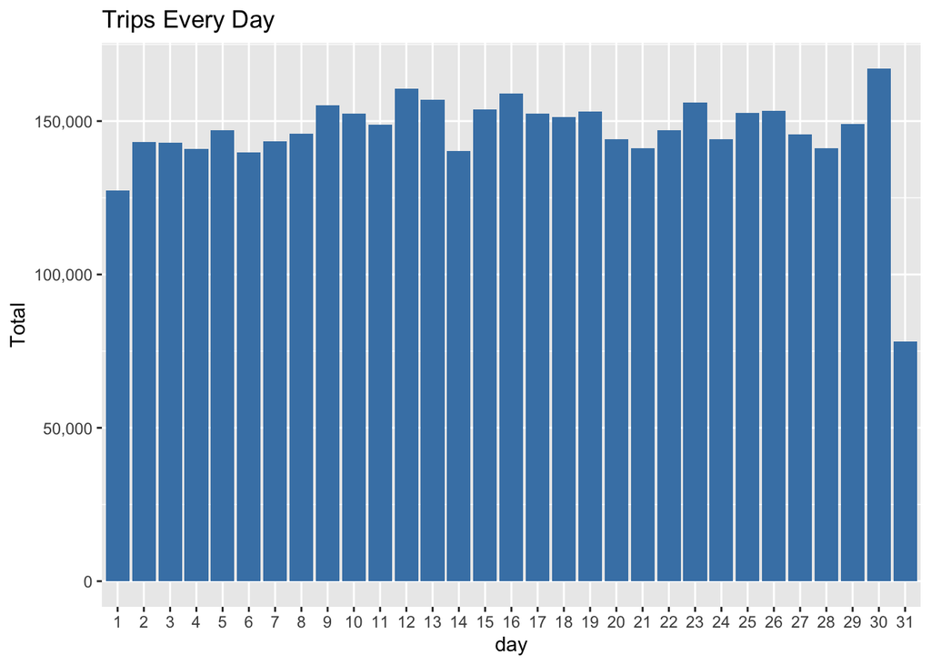

```r
ggplot(day_group, aes(day, Total)) +
  geom_bar( stat = "identity", fill = "steelblue") +
  ggtitle("Trips Every Day") +
  theme(legend.position = "none") +
  scale_y_continuous(labels = comma)
```

```r
day_month_group = data_2014 %>%
  group_by(month, day) %>%
    dplyr::summarize(Total = n())
```

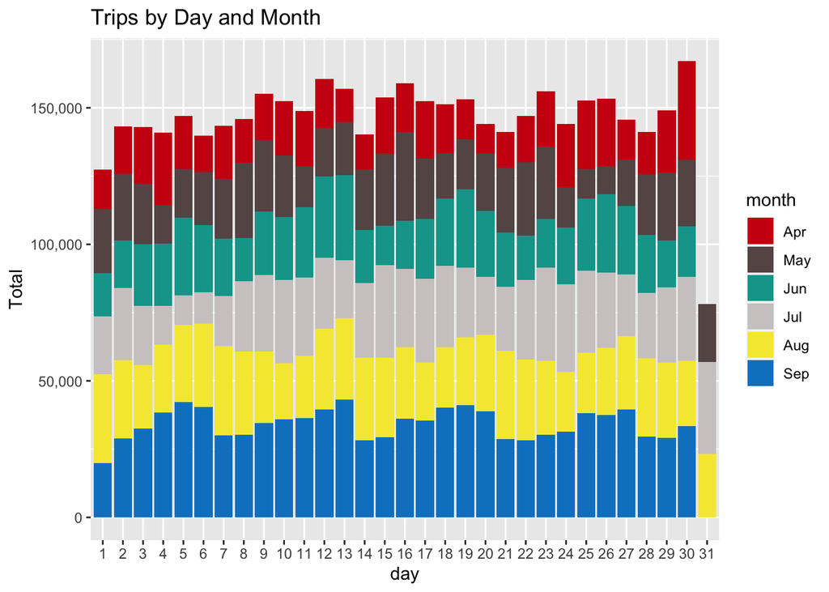

```r
ggplot(day_month_group, aes(day, Total, fill = month)) +
  geom_bar( stat = "identity") +
  ggtitle("Trips by Day and Month") +
  scale_y_continuous(labels = comma) +
  scale_fill_manual(values = colors)
```

The 30th of the month had the highest number of trips in the year. This is mostly contributed by the month of April.

### Visualize the number of trips that are taking place each month of the year

```r
month_group = data_2014 %>%
  group_by(month) %>%
    dplyr::summarize(Total = n())
datatable(month_group)
```

|  | month | Total |
| --- | --- | --- |
| 1 | Apr | 564516 |
| 2 | May | 652435 |
| 3 | Jun | 663844 |
| 4 | Jul | 796121 |
| 5 | Aug | 829275 |
| 6 | Sep | 1028136 |

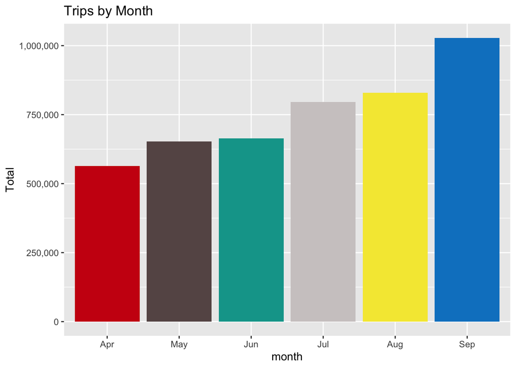

```r
ggplot(month_group , aes(month, Total, fill = month)) +
  geom_bar( stat = "identity") +
  ggtitle("Trips by Month") +
  theme(legend.position = "none") +
  scale_y_continuous(labels = comma) +
  scale_fill_manual(values = colors)
```

Most trips were made during the month of September.

### Visualize the number of trips that were made on every day of the week

```r
month_weekday = data_2014 %>%
  group_by(month, dayofweek) %>%
    dplyr::summarize(Total = n())
```

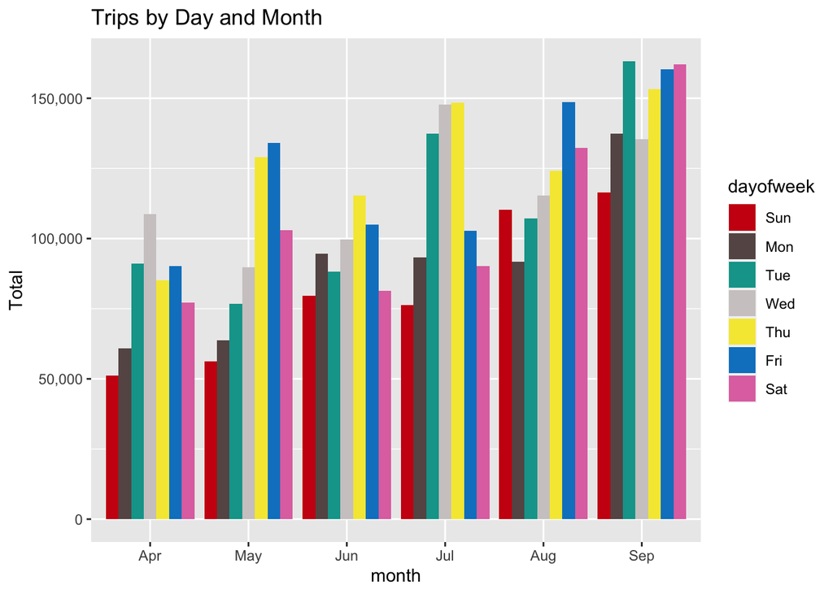

```r
ggplot(month_weekday, aes(month, Total, fill = dayofweek)) +
  geom_bar( stat = "identity", position = "dodge") +
  ggtitle("Trips by Day and Month") +
  scale_y_continuous(labels = comma) +
  scale_fill_manual(values = colors)
```

The busiest day of the week for Uber rides varies significantly by month.

## Analyze number of trips over different bases

### Visualize the number of trips taken from each of the bases

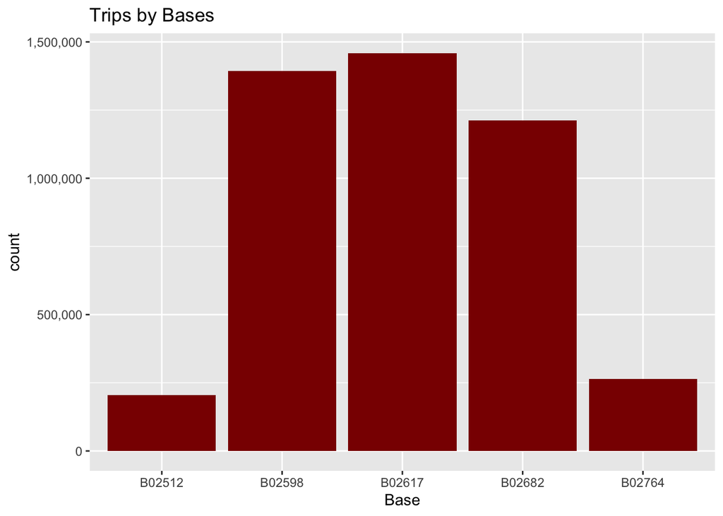

```r
ggplot(data_2014, aes(Base)) +
  geom_bar(fill = "darkred") +
  scale_y_continuous(labels = comma) +
  ggtitle("Trips by Bases")
```

There are five bases in all out of which, we observe that B02617 had the highest number of trips.

### Visualize the number of trips taken from each base during each month

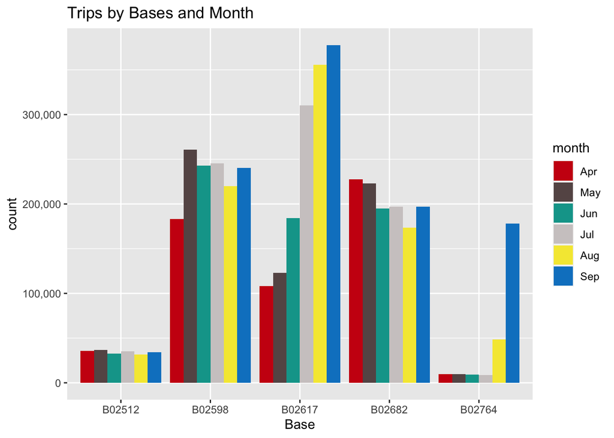

```r
ggplot(data_2014, aes(Base, fill = month)) +
  geom_bar(position = "dodge") +
  scale_y_continuous(labels = comma) +
  ggtitle("Trips by Bases and Month") +
  scale_fill_manual(values = colors)
```

B02617 had the highest number of trips in July, August, and September.

### Visualize the number of trips taken from each base during each day of the week

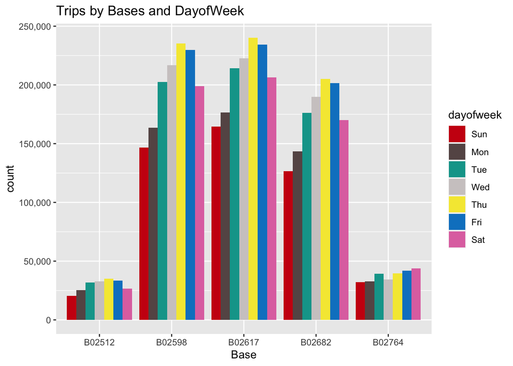

```r
ggplot(data_2014, aes(Base, fill = dayofweek)) +
  geom_bar(position = "dodge") +
  scale_y_continuous(labels = comma) +
  ggtitle("Trips by Bases and DayofWeek") +
  scale_fill_manual(values = colors)
```

Thursday observed highest trips in the three bases – B02598, B02617, B02682.

### Create a heatmap visualization by hour and day

```r
day_and_hour = data_2014 %>%
  group_by(day, hour) %>%
    dplyr::summarize(Total = n())
datatable(day_and_hour)
```

|  | day | hour | Total |
| --- | --- | --- | --- |
| 1 | 1 | 0 | 3247 |
| 2 | 1 | 1 | 1982 |
| 3 | 1 | 2 | 1284 |
| 4 | 1 | 3 | 1331 |
| 5 | 1 | 4 | 1458 |
| 6 | 1 | 5 | 2171 |
| 7 | 1 | 6 | 3717 |
| 8 | 1 | 7 | 5470 |
| 9 | 1 | 8 | 5376 |
| 10 | 1 | 9 | 4688 |

[output cut: 734 more lines]

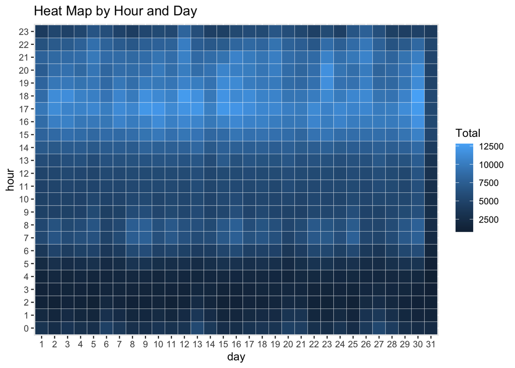

```r
ggplot(day_and_hour, aes(day, hour, fill = Total)) +
  geom_tile(color = "white") +
  ggtitle("Heat Map by Hour and Day")
```

### Create a heatmap visualization by month and day

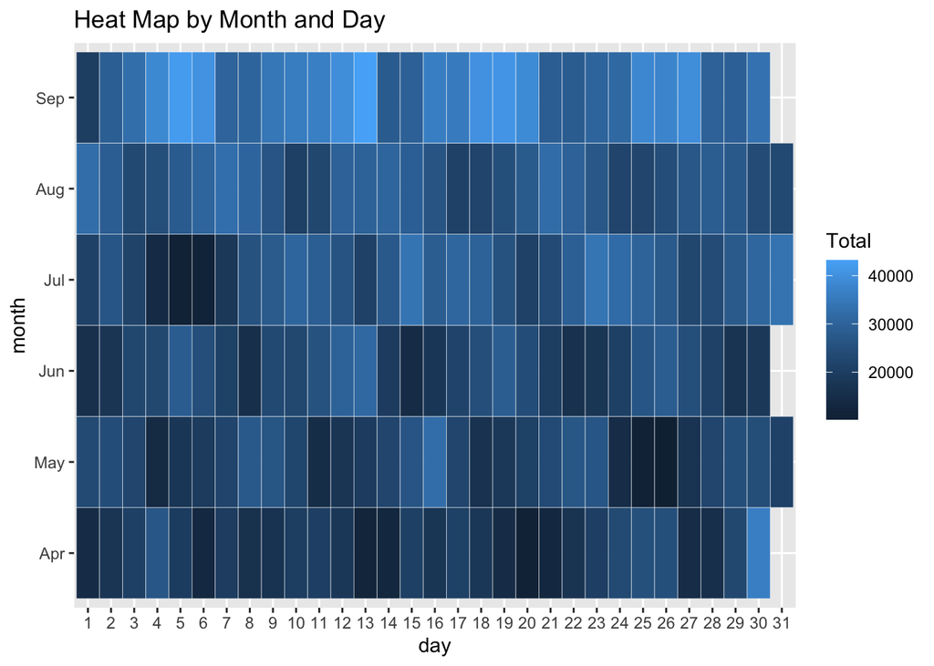

```r
ggplot(day_month_group, aes(day, month, fill = Total)) +
  geom_tile(color = "white") +
  ggtitle("Heat Map by Month and Day")
```

### Create a heatmap visualization by month and day of the week

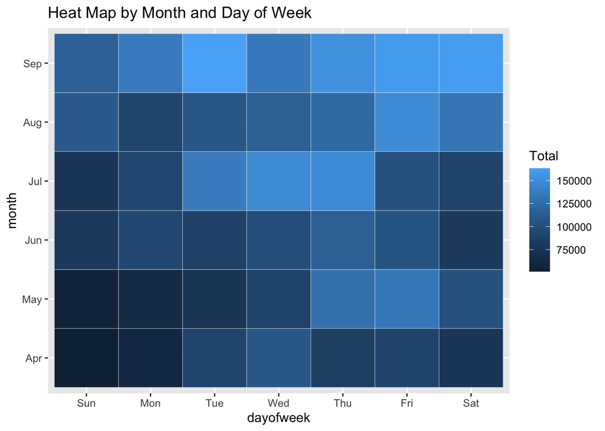

```r
ggplot(month_weekday, aes(dayofweek, month, fill = Total)) +
  geom_tile(color = "white") +
  ggtitle("Heat Map by Month and Day of Week")
```

### Create a heatmap visualization by bases and month

```r
month_base = data_2014 %>%
  group_by(Base, month) %>%
    dplyr::summarize(Total = n())
```

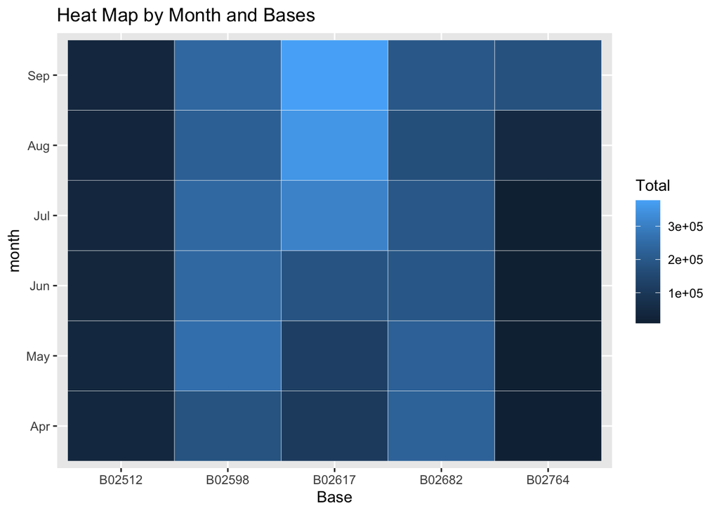

```r
ggplot(month_base, aes(Base, month, fill = Total)) +
  geom_tile(color = "white") +
  ggtitle("Heat Map by Month and Bases")
```

### Create a heatmap visualization by bases and day of the week

```r
day0fweek_bases = data_2014 %>%
  group_by(Base, dayofweek) %>%
    dplyr::summarize(Total = n())
```

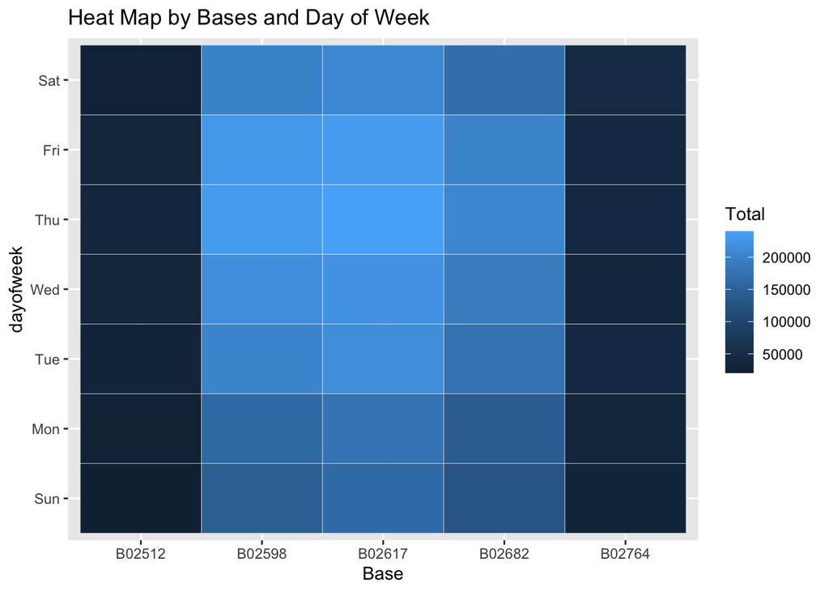

```r
ggplot(day0fweek_bases, aes(Base, dayofweek, fill = Total)) +
  geom_tile(color = "white") +
  ggtitle("Heat Map by Bases and Day of Week")
```

## Create a map visualization of rides in New York city

Creating a geo-plot that will help us to visualize the rides during 2014 (Apr – Sep) and by the bases in the same period.

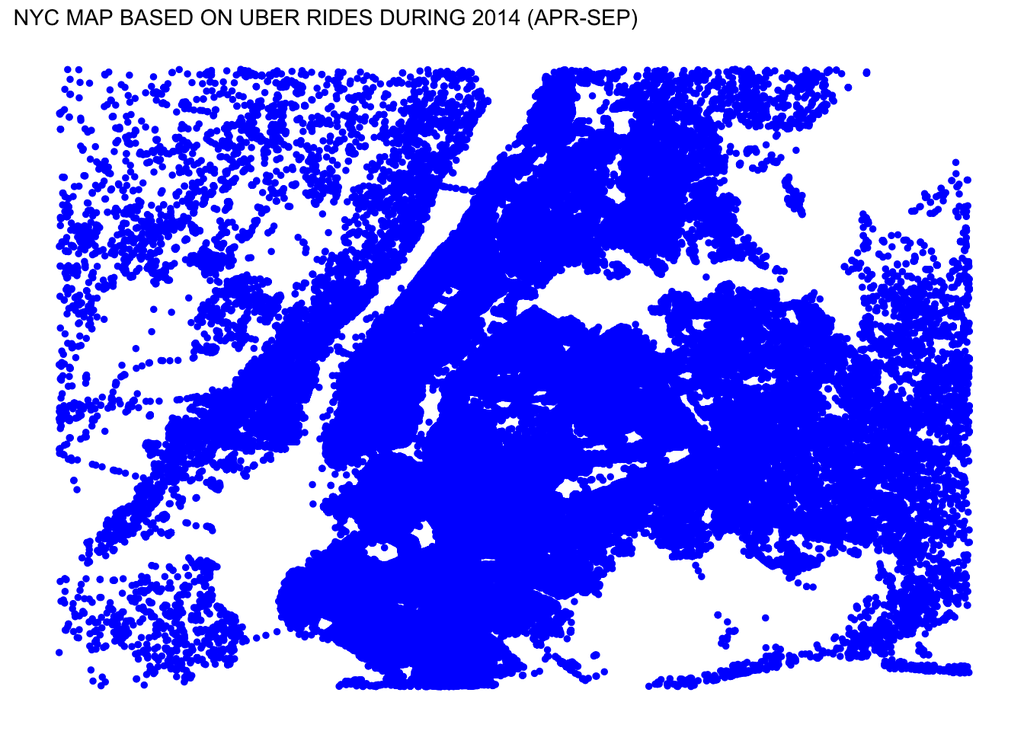

```r
min_lat = 40.5774
max_lat = 40.9176
min_long = -74.15
max_long = -73.7004

ggplot(data_2014, aes(x=Lon, y=Lat)) +
  geom_point(size=1, color = "blue") +
  scale_x_continuous(limits=c(min_long, max_long)) +
  scale_y_continuous(limits=c(min_lat, max_lat)) +
  theme_map() +
  ggtitle("NYC MAP BASED ON UBER RIDES DURING 2014 (APR-SEP)")
```

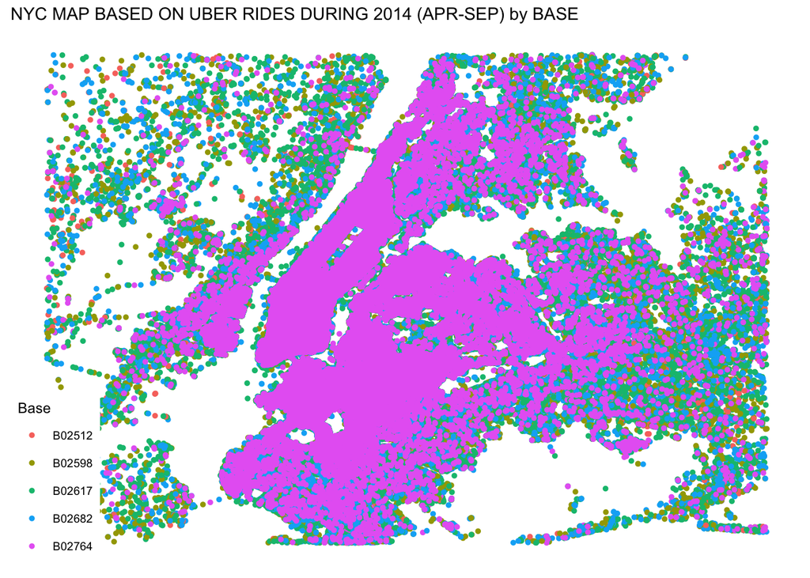

```r
ggplot(data_2014, aes(x=Lon, y=Lat, color = Base)) +
  geom_point(size=1) +
  scale_x_continuous(limits=c(min_long, max_long)) +
  scale_y_continuous(limits=c(min_lat, max_lat)) +
  theme_map() +
  ggtitle("NYC MAP BASED ON UBER RIDES DURING 2014 (APR-SEP) by BASE")
```

It is clear that Uber rides have occurred in almost every corner of New York City. This is why, by plotting the latitude and longitude of the start of each ride, we can almost completely recreate a map of New York City.